# ChipSeq coverage maps for DLG2

This document details working with aligned ChIPseq data to look at conservation of FLI1 peaks for DLG2.

## Setting up the environment

These are packages you will need for this notebook. For exact versions used, please refer to the session info at the bottom of this notebook.

```r
##########################################################################################
library('tidyverse')
library('ggplot2')
library('RColorBrewer')
library('wiggleplotr')
library('GenomicRanges')
library('rtracklayer')
```

I want to set a base directory that we can use as a link to the directory where we will do most of the work. I use two directories here because the Workspace is what is pushed to GitHub and contains scripts and plot files, but the Repository is where more of the big data is stored that does not get pushed.

```r
##########################################################################################
generalDatasets = 'C:/Users/chughes/Documents/bccrc/projectsRepository/generalDatasets'
baseWorkspace = 'C:/Users/chughes/Documents/bccrc/projectsWorkspace/sorensenLab/relatedToDlg2'
baseRepository = 'C:/Users/chughes/Documents/bccrc/projectsRepository/sorensenLab/relatedToDlg2'
#generalDatasets = 'C:/Users/chris/OneDrive/Documents/bccrc/projectsRepository/generalDatasets'
#baseWorkspace = 'C:/Users/chris/OneDrive/Documents/bccrc/projectsWorkspace/sorensenLab/relatedToYbx1'
#baseRepository = 'C:/Users/chris/OneDrive/Documents/bccrc/projectsRepository/sorensenLab/relatedToYbx1'
```

## Data processing

First get the gtf file we used for alignment and will use for annotation below.

```r
##########################################################################################
totalGtf = as.data.frame(rtracklayer::import.gff('D:/databases/projectEwsDlg2/refseqFiles/GRCh38_latest_genomic.gtf.gz'))
```

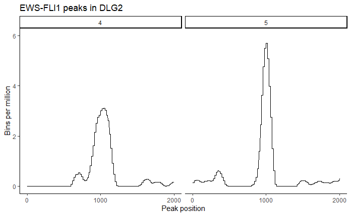

```r
##########################################################################################
#the transcript with the closest 'exon' is NM_001377978.1
dlg2Gtf = totalGtf %>%
  filter(grepl('DLG2$', gene)) %>%
  filter(grepl('gene', type)) %>%
  mutate(end = end + 100000) #we add 100kb here to search beyond the annotated TSS


##now we use the Aynaud data to define the peak regions
macsPeaks = read_tsv(paste(baseRepository, '/sequencing20210114_a673ChipSeqReprocessingAynaud/SRR8832674_peaks.xls', sep = ''),
                     skip = 30,
                     col_names = c('chr','start','end','length','abs_summit','pileup','logPValue','fold_enrichment','logQValue','name')) %>%
  filter(grepl('chr11', chr)) %>%
  filter(start > dlg2Gtf$start & end < dlg2Gtf$end) %>%
  mutate(midPoint = start + round(length / 2, 0)) %>%
  filter(fold_enrichment >= 10)
macsPeaks = macsPeaks[1:2,] #only keep peaks 90 and 91, as these are the ones with ggaa msats


##
#get the bigwig data, also from the Aynaud study
macsBw = rtracklayer::import(paste(baseRepository, '/sequencing20210114_a673ChipSeqReprocessingAynaud/SRR8832674.chr11.bw', sep = ''))


#make a grange that covers the peak regions
peakGrange = makeGRangesFromDataFrame(data.frame('seqname' = macsPeaks$chr,
                        'start' = macsPeaks$midPoint - 1000,
                        'end' = macsPeaks$midPoint + 1000,
                        'strand' = '*'))


#find the overlaps with the bigwig data
peakWindows = unlist(slidingWindows(peakGrange,1), use.names = TRUE)
peakWindows$peak = rep(seq(5,4,-1), each = 2001)
macsOverlaps = findOverlaps(peakWindows, macsBw, ignore.strand = TRUE)
macsCounts = as.data.frame(macsBw)[subjectHits(macsOverlaps),]
macsCounts$peakId = peakWindows$peak
macsCounts$indexLocation = rep(seq(1,2001,1), 2)

#make a test plot
ggplot(macsCounts, aes(indexLocation, score)) +
  geom_path() +
  scale_y_continuous(limits = c(0,6), breaks = seq(0,8,2)) +
  scale_x_continuous(limits = c(0,2005), breaks = seq(0,2000,1000)) +
  labs(x = 'Peak position', y = 'Bins per million', title = 'EWS-FLI1 peaks in DLG2') +
  theme_classic() +
  facet_wrap(~peakId, nrow = 1)

##looks good, so make a plot for each
accessions = c(paste('SRR147',seq(60997,61017,5),sep=''),
               paste('SRR147',seq(61027,61052,5),sep=''),
               paste('SRR147',seq(61058,61083,5),sep=''))

for(i in 1:length(accessions)){
  macsBw = rtracklayer::import(paste(baseRepository, '/sequencing20211027_grunewaldEwsEncyclopedia/coverageAnalysis/',accessions[i],'.chr11.bw', sep = ''))
  macsOverlaps = findOverlaps(peakWindows, macsBw, ignore.strand = TRUE)
  macsCounts = as.data.frame(macsBw)[subjectHits(macsOverlaps),]
  macsCounts$peakId = peakWindows$peak
  macsCounts$indexLocation = rep(seq(1,2001,1), 2)
  ##
  ggplot(macsCounts, aes(indexLocation, score)) +
    geom_path() +
    #scale_y_continuous(limits = c(0,6), breaks = seq(0,8,2)) +
    scale_x_continuous(limits = c(0,2005), breaks = seq(0,2000,1000)) +
    labs(x = 'Peak position', y = 'Bins per million', title = 'EWS-FLI1 peaks in DLG2') +
    theme_classic() +
    theme(panel.border = element_rect(size = 1, fill = NA)) +
    facet_wrap(~peakId, nrow = 1)
  ggsave(paste(baseRepository, '/sequencing20211027_grunewaldEwsEncyclopedia/coverageAnalysis/lineplot_dlg2ChipPeaks',accessions[i],'.pdf', sep = ''),
         height = 4, width = 4, useDingbats = FALSE)
}
```

Make plots of each individual peak across the different cell lines.

```r
##########################################################################################
#need to run the code above before you run this chunk
sampleAnno = tibble('accession' = accessions,
                    'cellLine' = c('A673','CHLA10','CHLA25','EW1','EW22','EW3',
                                   'EW7','MHHES1','MIC','POE','RDES','RH1',
                                   'SKES1','SKNMC','TC32','TC71','TC106'))
##
peakData = tibble()
for(i in 1:length(accessions)){
  macsBw = rtracklayer::import(paste(baseRepository, '/sequencing20211027_grunewaldEwsEncyclopedia/coverageAnalysis/',accessions[i],'.chr11.bw', sep = ''))
  macsOverlaps = findOverlaps(peakWindows, macsBw, ignore.strand = TRUE)
  macsCounts = as.data.frame(macsBw)[subjectHits(macsOverlaps),]
  macsCounts$peakId = peakWindows$peak
  macsCounts$indexLocation = rep(seq(1,2001,1), 2)
  macsCounts$accession = accessions[i]
  macsCounts$adjustedScore = (macsCounts$score / sum(macsBw$score)) * 1e6
  macsCountsAnno = macsCounts %>%
    left_join(sampleAnno)
  peakData = rbind(peakData, macsCountsAnno)
}
##
#you can use adjusted score to check if the low coverage is a result of low overall coverage, but it is not the case
for (i in c(4,5)){
  peakPlot = dplyr::filter(peakData, peakId == i)
  peakMax = peakPlot %>%
    dplyr::select(cellLine, peakId, score) %>%
    dplyr::group_by(cellLine, peakId) %>%
    dplyr::summarise(peakMaxScore = max(score)) %>%
    dplyr::arrange(-peakMaxScore)
  print(peakMax)
  ggplot(peakPlot, aes(indexLocation, score)) +
    geom_path(aes(group = cellLine), color = brewer.pal(3,'Blues')[3], alpha = 0.5, size = 0.5) +
    scale_x_continuous(limits = c(0,2005), breaks = seq(0,2000,1000)) +
    scale_y_continuous(limits = c(0,26), breaks = seq(0,60,5)) +
    labs(x = 'Peak position', y = 'Coverage', title = 'EWS-FLI1 peaks in DLG2') +
    theme_classic()
  ggsave(paste(baseRepository, '/sequencing20211027_grunewaldEwsEncyclopedia/coverageAnalysis/lineplot_dlg2ChipPeak',i,'AllCellLines.pdf', sep = ''),
         height = 2, width = 2, useDingbats = FALSE)
}
```

| cellLine | peakId | peakMaxScore |
| --- | --- | --- |
| TC71 | 4 | 25.55530 |
| TC106 | 4 | 19.70500 |
| RDES | 4 | 14.38430 |
| SKES1 | 4 | 12.71170 |
| A673 | 4 | 12.25660 |
| RH1 | 4 | 7.20375 |
| SKNMC | 4 | 6.55809 |
| EW22 | 4 | 6.39123 |
| EW1 | 4 | 6.17890 |
| CHLA10 | 4 | 6.04842 |

[output cut: 7 more lines]

| cellLine | peakId | peakMaxScore |
| --- | --- | --- |
| TC71 | 5 | 19.56110 |
| RH1 | 5 | 15.54400 |
| TC106 | 5 | 14.97220 |
| A673 | 5 | 13.65920 |
| RDES | 5 | 13.13790 |
| EW22 | 5 | 11.11600 |
| SKNMC | 5 | 10.08470 |
| SKES1 | 5 | 9.91747 |
| EW1 | 5 | 9.57167 |
| CHLA10 | 5 | 9.16187 |

[output cut: 7 more lines]

We also have H3K27Ac and some other data here.

```r
##########################################################################################
#need to run the code above before you run this chunk
accessions = c(paste('SRR147',seq(61000,61020,5),sep=''),
               paste('SRR147',seq(61030,61050,5),sep=''),
               paste('SRR147',seq(61056,61086,5),sep=''))
sampleAnno = tibble('accession' = accessions,
                    'cellLine' = c('A673','CHLA10','CHLA25','EW1','EW22','EW3',
                                   'EW7','MHHES1','MIC','POE','RDES','RH1',
                                   'SKES1','SKNMC','TC32','TC71','TC106'))
##
peakData = tibble()
for(i in 1:length(accessions)){
  macsBw = rtracklayer::import(paste(baseRepository, '/sequencing20211027_grunewaldEwsEncyclopedia/coverageAnalysis/',accessions[i],'.chr11.bw', sep = ''))
  macsOverlaps = findOverlaps(peakWindows, macsBw, ignore.strand = TRUE)
  macsCounts = as.data.frame(macsBw)[subjectHits(macsOverlaps),]
  macsCounts$peakId = peakWindows$peak
  macsCounts$indexLocation = rep(seq(1,2001,1), 2)
  macsCounts$accession = accessions[i]
  macsCounts$adjustedScore = (macsCounts$score / sum(macsBw$score)) * 1e6
  macsCountsAnno = macsCounts %>%
    left_join(sampleAnno)
  peakData = rbind(peakData, macsCountsAnno)
}
##
#you can use adjusted score to check if the low coverage is a result of low overall coverage, but it is not the case
for (i in c(4,5)){
  peakPlot = dplyr::filter(peakData, peakId == i)
  peakMax = peakPlot %>%
    dplyr::select(cellLine, peakId, score) %>%
    dplyr::group_by(cellLine, peakId) %>%
    dplyr::summarise(peakMaxScore = max(score)) %>%
    dplyr::arrange(-peakMaxScore)
  print(peakMax)
  ggplot(peakPlot, aes(indexLocation, score)) +
    geom_path(aes(group = cellLine), color = brewer.pal(3,'Blues')[3], alpha = 0.5, size = 0.5) +
    scale_x_continuous(limits = c(0,2005), breaks = seq(0,2000,1000)) +
    scale_y_continuous(limits = c(0,26), breaks = seq(0,60,5)) +
    labs(x = 'Peak position', y = 'Coverage', title = 'EWS-FLI1 peaks in DLG2') +
    theme_classic()
  ggsave(paste(baseRepository, '/sequencing20211027_grunewaldEwsEncyclopedia/coverageAnalysis/lineplot_dlg2H3K27Ac',i,'AllCellLines.pdf', sep = ''),
         height = 2, width = 2, useDingbats = FALSE)
}
```

| cellLine | peakId | peakMaxScore |
| --- | --- | --- |
| SKNMC | 4 | 2.852410 |
| CHLA10 | 4 | 2.786090 |
| RDES | 4 | 2.620380 |
| SKES1 | 4 | 2.397690 |
| EW3 | 4 | 2.380120 |
| EW1 | 4 | 2.217440 |
| MHHES1 | 4 | 2.082990 |
| EW7 | 4 | 2.008840 |
| RH1 | 4 | 1.799270 |
| TC32 | 4 | 1.724050 |

[output cut: 7 more lines]

| cellLine | peakId | peakMaxScore |
| --- | --- | --- |
| EW3 | 5 | 5.97598 |
| CHLA25 | 5 | 4.80250 |
| SKNMC | 5 | 4.27320 |
| MHHES1 | 5 | 4.09332 |
| SKES1 | 5 | 4.07965 |
| RDES | 5 | 3.97910 |
| CHLA10 | 5 | 3.69113 |
| EW1 | 5 | 3.47874 |
| POE | 5 | 3.41423 |
| EW7 | 5 | 3.30425 |

[output cut: 7 more lines]

We can also combine all of these data. In the end I don’t think I used this because they are too different.

```r
##########################################################################################
accessions = c(paste('SRR147',seq(60997,61017,5),sep=''),
               paste('SRR147',seq(61027,61052,5),sep=''),
               paste('SRR147',seq(61058,61083,5),sep=''))
##
sampleAnno = tibble('accession' = accessions,
                    'cellLine' = c('A673','CHLA10','CHLA25','EW1','EW22','EW3',
                                   'EW7','MHHES1','MIC','POE','RDES','RH1',
                                   'SKES1','SKNMC','TC32','TC71','TC106'))

#make a grange that covers the peak regions, macsPeaks object is created in the code above
peakGrange = makeGRangesFromDataFrame(data.frame('seqname' = macsPeaks$chr,
                        'start' = macsPeaks$midPoint - 500,
                        'end' = macsPeaks$midPoint + 500,
                        'strand' = '*'))
peakWindows = unlist(slidingWindows(peakGrange,1), use.names = TRUE)
peakWindows$peak = rep(seq(5,4,-1), each = 1001)

##this is the FLI1 bait data
ipBait = 'FLI1'
ipData = tibble()
for(i in 1:length(accessions)){
  macsBw = rtracklayer::import(paste(baseRepository, '/sequencing20211027_grunewaldEwsEncyclopedia/coverageAnalysis/',accessions[i],'.chr11.bw', sep = ''))
  macsOverlaps = findOverlaps(peakWindows, macsBw, ignore.strand = TRUE)
  macsCounts = as.data.frame(macsBw)[subjectHits(macsOverlaps),]
  macsCounts$peakId = peakWindows$peak
  macsCounts$indexLocation = rep(seq(1,1001,1), 2)
  macsCounts$accession = accessions[i]
  macsCountsAnno = macsCounts %>%
    left_join(sampleAnno)
  ##
  peakMaxJoin = tibble('cellLine' = as.character(sampleAnno[i,2]))
  for (j in c(4,5)){
    macsCountsSubset = dplyr::filter(macsCountsAnno, peakId == j)
    peakMax = macsCountsSubset %>%
      dplyr::select(cellLine, score) %>%
      dplyr::group_by(cellLine) %>%
      dplyr::summarise(peakMaxScore = max(score))
    colnames(peakMax)[2] = paste('peak',j,ipBait,'Score',sep='')
    peakMaxJoin = dplyr::left_join(peakMaxJoin, peakMax)
  }
  ipData = rbind(ipData, peakMaxJoin)
}
##this is the H3K4me3 bait data
accessions = c(paste('SRR147',seq(60998,61018,5),sep=''),
               paste('SRR147',seq(61028,61053,5),sep=''),
               paste('SRR147',seq(61059,61084,5),sep=''))
##
sampleAnno = tibble('accession' = accessions,
                    'cellLine' = c('A673','CHLA10','CHLA25','EW1','EW22','EW3',
                                   'EW7','MHHES1','MIC','POE','RDES','RH1',
                                   'SKES1','SKNMC','TC32','TC71','TC106'))
##
ipBait = 'H3K4me3'
ipData2 = tibble()
for(i in 1:length(accessions)){
  macsBw = rtracklayer::import(paste(baseRepository, '/sequencing20211027_grunewaldEwsEncyclopedia/coverageAnalysis/',accessions[i],'.chr11.bw', sep = ''))
  macsOverlaps = findOverlaps(peakWindows, macsBw, ignore.strand = TRUE)
  macsCounts = as.data.frame(macsBw)[subjectHits(macsOverlaps),]
  macsCounts$peakId = peakWindows$peak
  macsCounts$indexLocation = rep(seq(1,1001,1), 2)
  macsCounts$accession = accessions[i]
  macsCountsAnno = macsCounts %>%
    left_join(sampleAnno)
  ##
  peakMaxJoin = tibble('cellLine' = as.character(sampleAnno[i,2]))
  for (j in c(4,5)){
    macsCountsSubset = dplyr::filter(macsCountsAnno, peakId == j)
    peakMax = macsCountsSubset %>%
      dplyr::select(cellLine, score) %>%
      dplyr::group_by(cellLine) %>%
      dplyr::summarise(peakMaxScore = max(score))
    colnames(peakMax)[2] = paste('peak',j,ipBait,'Score',sep='')
    peakMaxJoin = dplyr::left_join(peakMaxJoin, peakMax)
  }
  ipData2 = rbind(ipData2, peakMaxJoin)
}
##this is the H3K27me3 bait data
accessions = c(paste('SRR147',seq(60999,61019,5),sep=''),
               paste('SRR147',seq(61029,61049,5),sep=''),
               paste('SRR147',seq(61055,61085,5),sep=''))
##
sampleAnno = tibble('accession' = accessions,
                    'cellLine' = c('A673','CHLA10','CHLA25','EW1','EW22','EW3',
                                   'EW7','MHHES1','MIC','POE','RDES','RH1',
                                   'SKES1','SKNMC','TC32','TC71','TC106'))
##
ipBait = 'H3K27me3'
ipData3 = tibble()
for(i in 1:length(accessions)){
  macsBw = rtracklayer::import(paste(baseRepository, '/sequencing20211027_grunewaldEwsEncyclopedia/coverageAnalysis/',accessions[i],'.chr11.bw', sep = ''))
  macsOverlaps = findOverlaps(peakWindows, macsBw, ignore.strand = TRUE)
  macsCounts = as.data.frame(macsBw)[subjectHits(macsOverlaps),]
  macsCounts$peakId = peakWindows$peak
  macsCounts$indexLocation = rep(seq(1,1001,1), 2)
  macsCounts$accession = accessions[i]
  macsCountsAnno = macsCounts %>%
    left_join(sampleAnno)
  ##
  peakMaxJoin = tibble('cellLine' = as.character(sampleAnno[i,2]))
  for (j in c(4,5)){
    macsCountsSubset = dplyr::filter(macsCountsAnno, peakId == j)
    peakMax = macsCountsSubset %>%
      dplyr::select(cellLine, score) %>%
      dplyr::group_by(cellLine) %>%
      dplyr::summarise(peakMaxScore = max(score))
    colnames(peakMax)[2] = paste('peak',j,ipBait,'Score',sep='')
    peakMaxJoin = dplyr::left_join(peakMaxJoin, peakMax)
  }
  ipData3 = rbind(ipData3, peakMaxJoin)
}
##this is the H3K27ac bait data
accessions = c(paste('SRR147',seq(61000,61020,5),sep=''),
               paste('SRR147',seq(61030,61050,5),sep=''),
               paste('SRR147',seq(61056,61086,5),sep=''))
##
sampleAnno = tibble('accession' = accessions,
                    'cellLine' = c('A673','CHLA10','CHLA25','EW1','EW22','EW3',
                                   'EW7','MHHES1','MIC','POE','RDES','RH1',
                                   'SKES1','SKNMC','TC32','TC71','TC106'))
##
ipBait = 'H3K27ac'
ipData4 = tibble()
for(i in 1:length(accessions)){
  macsBw = rtracklayer::import(paste(baseRepository, '/sequencing20211027_grunewaldEwsEncyclopedia/coverageAnalysis/',accessions[i],'.chr11.bw', sep = ''))
  macsOverlaps = findOverlaps(peakWindows, macsBw, ignore.strand = TRUE)
  macsCounts = as.data.frame(macsBw)[subjectHits(macsOverlaps),]
  macsCounts$peakId = peakWindows$peak
  macsCounts$indexLocation = rep(seq(1,1001,1), 2)
  macsCounts$accession = accessions[i]
  macsCountsAnno = macsCounts %>%
    left_join(sampleAnno)
  ##
  peakMaxJoin = tibble('cellLine' = as.character(sampleAnno[i,2]))
  for (j in c(4,5)){
    macsCountsSubset = dplyr::filter(macsCountsAnno, peakId == j)
    peakMax = macsCountsSubset %>%
      dplyr::select(cellLine, score) %>%
      dplyr::group_by(cellLine) %>%
      dplyr::summarise(peakMaxScore = max(score))
    colnames(peakMax)[2] = paste('peak',j,ipBait,'Score',sep='')
    peakMaxJoin = dplyr::left_join(peakMaxJoin, peakMax)
  }
  ipData4 = rbind(ipData4, peakMaxJoin)
}
###combine all of the data
allIpData = ipData %>%
  left_join(ipData2) %>%
  left_join(ipData3) %>%
  left_join(ipData4)
```

[session information not shown]